# SAGES - Predicting GCP slope

Author

Doug Tommet

Published

May 24, 2024

# Goals

## Overall goal

The overall goal is to build the two best prediction models for delirium and cognitive decline as possible given the data we collected. This is intended for a research audience because many of the variables going into this model would be difficult for clinicians to obtain.

## Today’s (2024-04-05) goal

Review the variables the expert panel voted to keep and the resulting principal compenent analysis.

## Today’s (2024-02-02) goal

Review the variables that made it through our selection process for inclusion into the model.

# Background

There are many interesting variables that could possibly included in our model. There are too many to reasonably include in any type of model given our sample size. So, we need a process to trim down our candidate variable list. The process we will use involves two (three?, four?) steps.

1. Variables with more than 50% missingness will be dropped. Those with less than 50% missingness will have values imputed using predictive mean matching.
2. Variables that lack any variability will be dropped. If a variable is an indicator for whether something happened, and only a few participants experienced the event, then even if the indicator is clinically meaningful, it will be dropped because it will make a poor predictor in the model.
3. Variables that are redundant with each other will be dropped. If a variable that can be reasonably well predicted by other variables in the model, then that variable is not providing much more to the model.
4. The remaining variables will be combined into principal components.

# Cognitive slope - model fit

The elastic net models were fit on four variable sets across two modeling approaches:

- The variable sets:
  - The first 15 PCA components from the set of 93 variables.
  - The set of 7 PCA components from the 7 variables that had three or more votes from the expert panel
  - The set of 14 PCA components from the 14 variables that had two or more votes from the expert panel
  - The first 15 PCA components from the 32 variables that had one or more votes from the expert panel
- The models:
  - original PCA components
  - restricted cubic splines of the first 15 PCA components

The random forest models were fit on four variable sets:

- The variable sets:
  - The first 15 PCA components from the set of 93 variables.
  - The set of 7 PCA components from the 7 variables that had three or more votes from the expert panel
  - The set of 14 PCA components from the 14 variables that had two or more votes from the expert panel
  - The first 15 PCA components from the 32 variables that had one or more votes from the expert panel

**Model tuning**

The training data was into 10 cross-validation sets.

The models were tuned to minimize the RMSE.

The elastic net models were tuned using 25 sets of possible values.

These are the hyperparameters that were tuned:

- Elastic net: alpha (mixture between lasso and ridge regression) and penalty term

The random forest models were tuned using 40 sets of possible values.

These are the hyperparameters that were tuned:

- Random forest: number of trees and minimum sample size per node

## GLMNET

### Original PCA components

#### Performance in testing set

Model using the first 15 of 93 PCA components.

```
# A tibble: 2 × 4
  .metric .estimator .estimate .config
  <chr>   <chr>          <dbl> <chr>
1 rmse    standard       0.700 Preprocessor1_Model1
2 rsq     standard       0.122 Preprocessor1_Model1
```

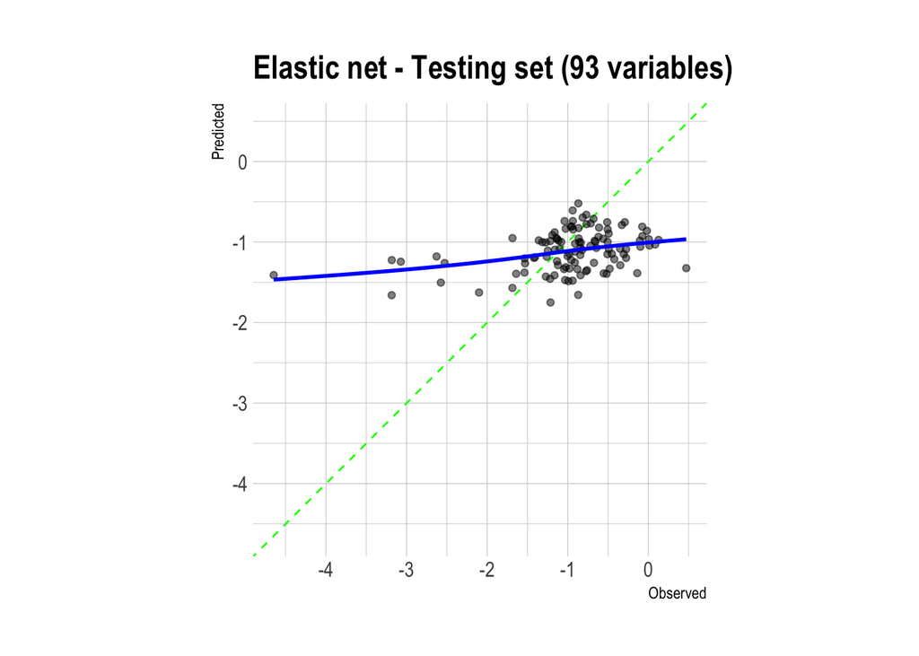

Model using the 7 PCA components from variables that had three or more votes from the expert panel.

```
# A tibble: 2 × 4
  .metric .estimator .estimate .config
  <chr>   <chr>          <dbl> <chr>
1 rmse    standard      0.724  Preprocessor1_Model1
2 rsq     standard      0.0777 Preprocessor1_Model1
```

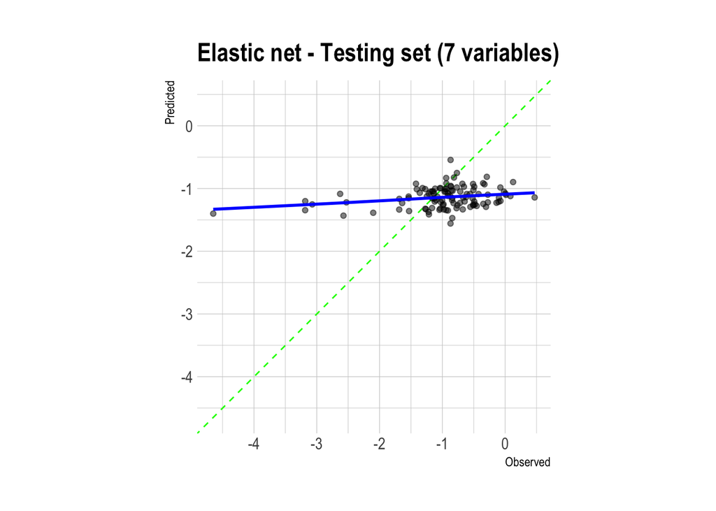

Model using the 14 PCA components from variables that had two or more votes from the expert panel.

```
# A tibble: 2 × 4
  .metric .estimator .estimate .config
  <chr>   <chr>          <dbl> <chr>
1 rmse    standard       0.699 Preprocessor1_Model1
2 rsq     standard       0.124 Preprocessor1_Model1
```

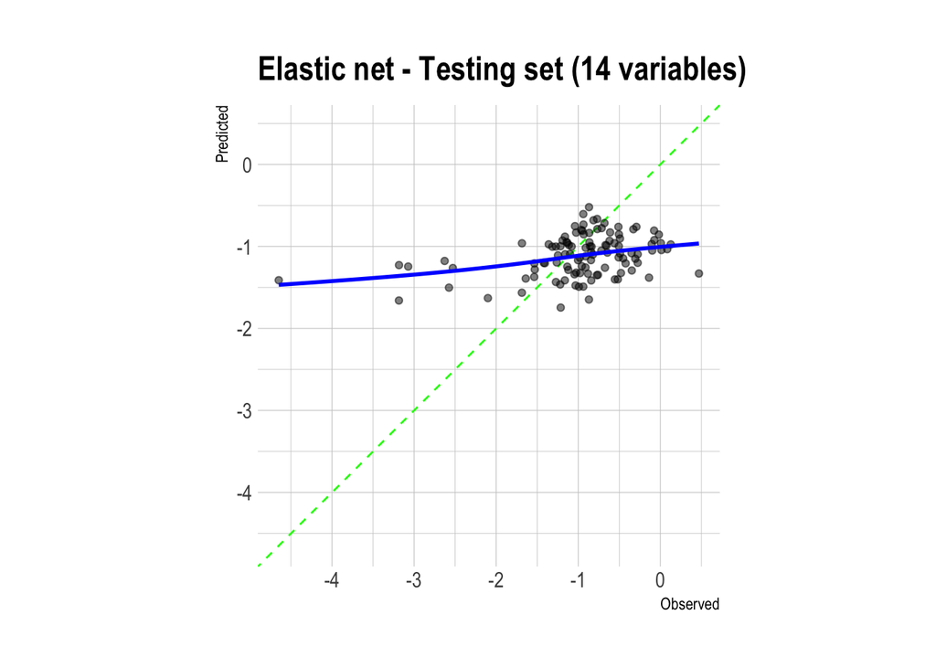

Model using the first 15 of 32 PCA components from variables that had one or more votes from the expert panel.

```
# A tibble: 2 × 4
  .metric .estimator .estimate .config
  <chr>   <chr>          <dbl> <chr>
1 rmse    standard       0.700 Preprocessor1_Model1
2 rsq     standard       0.122 Preprocessor1_Model1
```

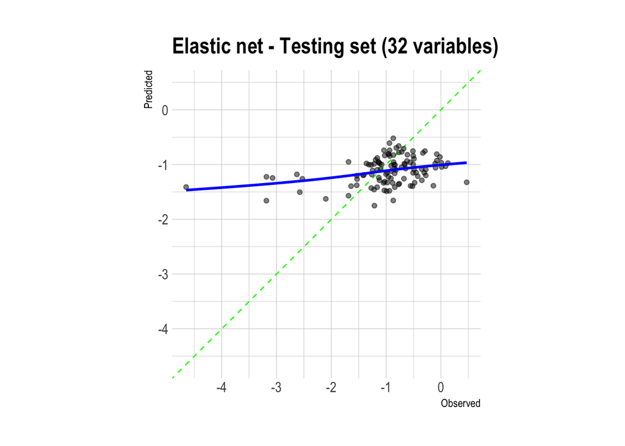

### Restricted cubic splines

#### Performance in testing set

Model using the first 15 of 93 PCA components.

```
# A tibble: 2 × 4
  .metric .estimator .estimate .config
  <chr>   <chr>          <dbl> <chr>
1 rmse    standard       0.695 Preprocessor1_Model1
2 rsq     standard       0.152 Preprocessor1_Model1
```

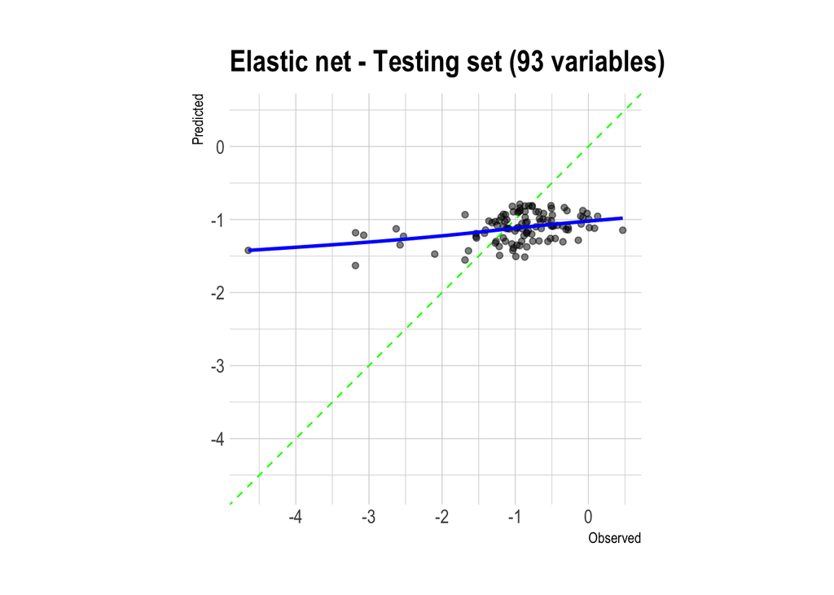

Model using the 7 PCA components from variables that had three or more votes from the expert panel.

```
# A tibble: 2 × 4
  .metric .estimator .estimate .config
  <chr>   <chr>          <dbl> <chr>
1 rmse    standard       0.715 Preprocessor1_Model1
2 rsq     standard       0.102 Preprocessor1_Model1
```

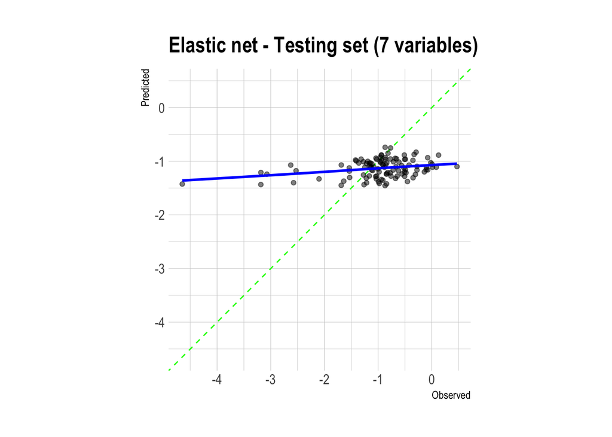

Model using the 14 PCA components from variables that had two or more votes from the expert panel.

```
# A tibble: 2 × 4
  .metric .estimator .estimate .config
  <chr>   <chr>          <dbl> <chr>
1 rmse    standard       0.695 Preprocessor1_Model1
2 rsq     standard       0.152 Preprocessor1_Model1
```

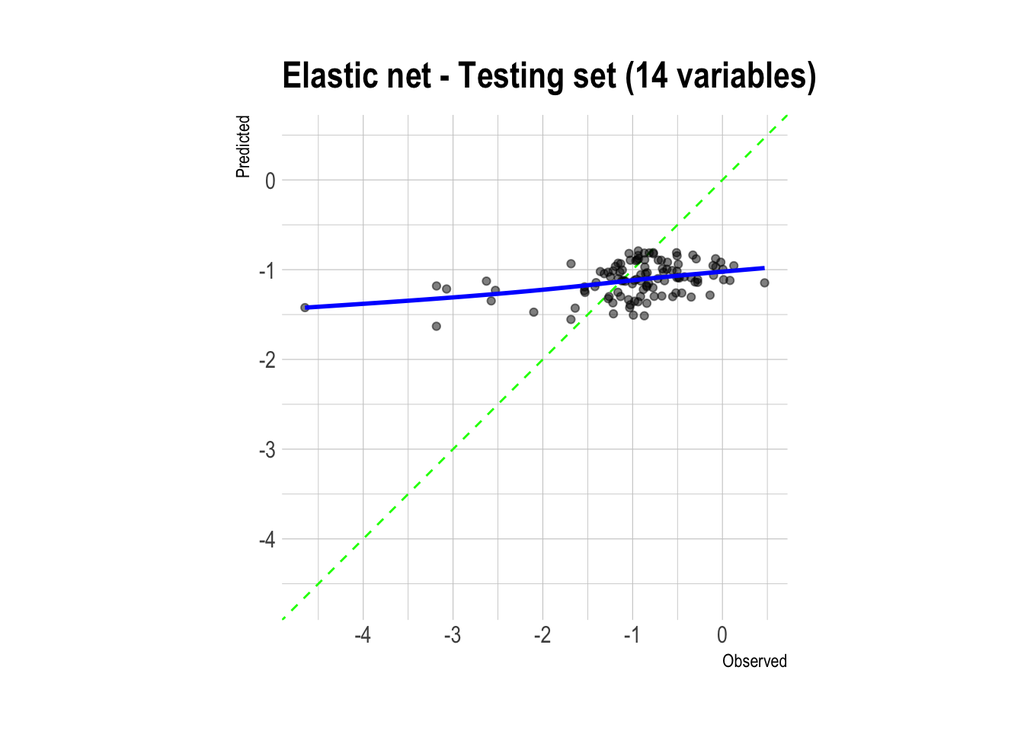

Model using the first 15 of 32 PCA components from variables that had one or more votes from the expert panel.

```
# A tibble: 2 × 4
  .metric .estimator .estimate .config
  <chr>   <chr>          <dbl> <chr>
1 rmse    standard       0.695 Preprocessor1_Model1
2 rsq     standard       0.152 Preprocessor1_Model1
```

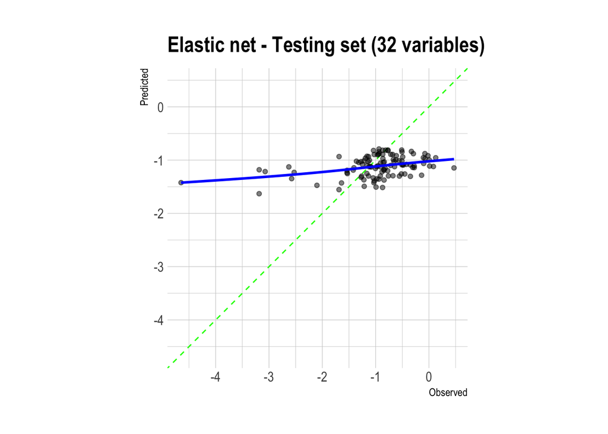

## Random forest

### Original PCA components

#### Performance in testing set

Model using the first 15 of 93 PCA components.

```
# A tibble: 2 × 4
  .metric .estimator .estimate .config
  <chr>   <chr>          <dbl> <chr>
1 rmse    standard      0.711  Preprocessor1_Model1
2 rsq     standard      0.0840 Preprocessor1_Model1
```

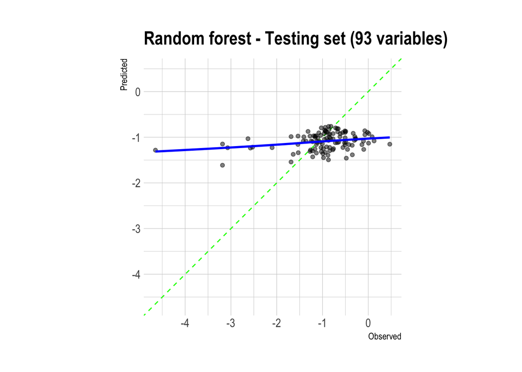

Model using the 7 PCA components from variables that had three or more votes from the expert panel.

```
# A tibble: 2 × 4
  .metric .estimator .estimate .config
  <chr>   <chr>          <dbl> <chr>
1 rmse    standard      0.732  Preprocessor1_Model1
2 rsq     standard      0.0442 Preprocessor1_Model1
```

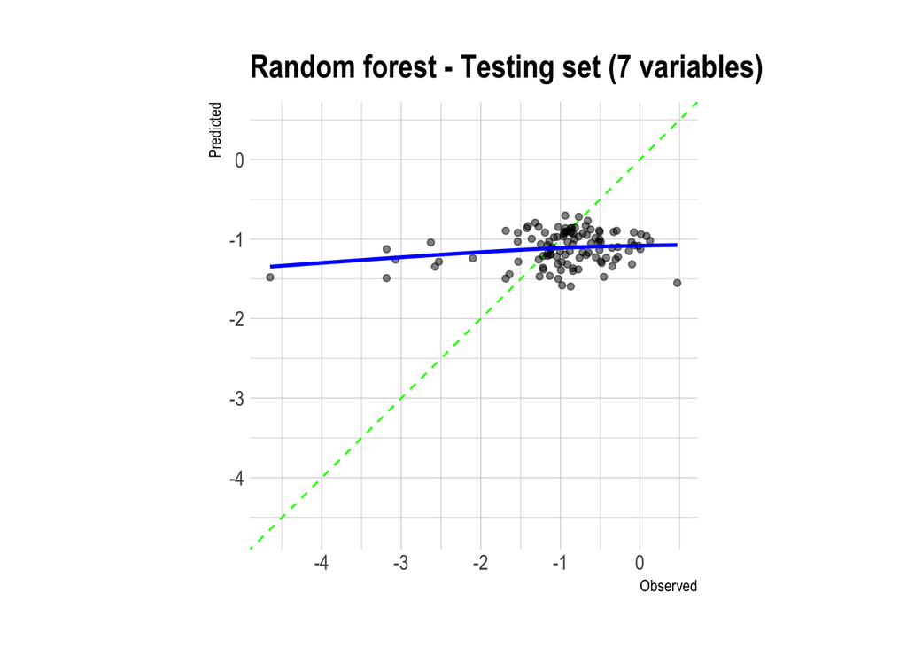

Model using the 14 PCA components from variables that had two or more votes from the expert panel.

```
# A tibble: 2 × 4
  .metric .estimator .estimate .config
  <chr>   <chr>          <dbl> <chr>
1 rmse    standard      0.717  Preprocessor1_Model1
2 rsq     standard      0.0745 Preprocessor1_Model1
```

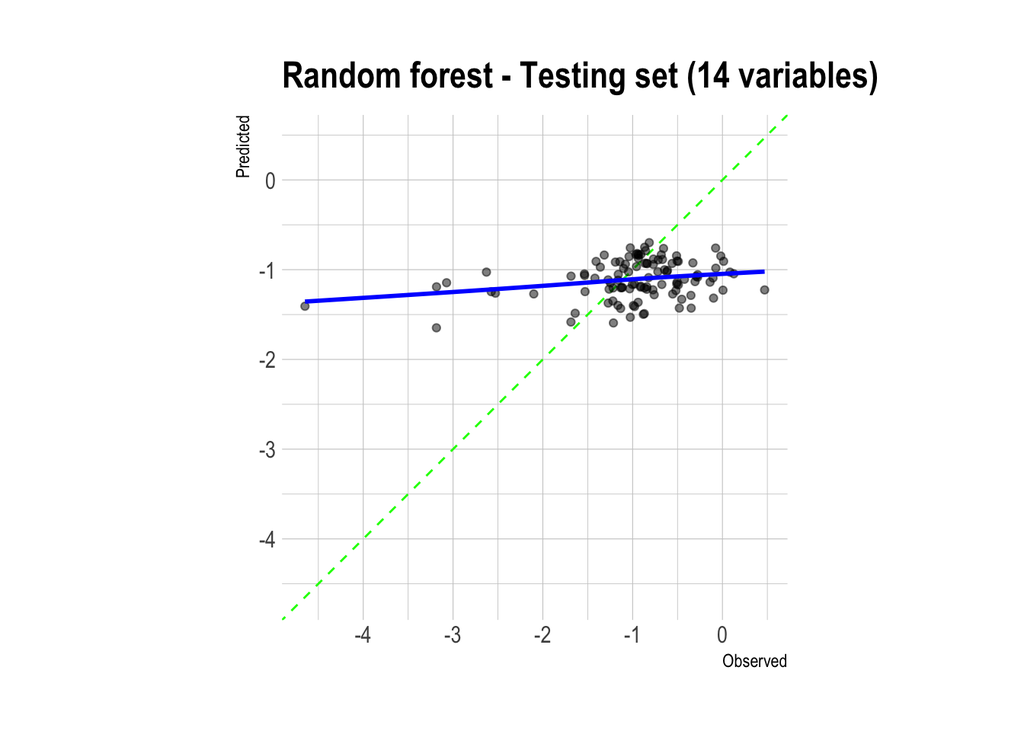

Model using the first 15 of 32 PCA components from variables that had one or more votes from the expert panel.

```
# A tibble: 2 × 4
  .metric .estimator .estimate .config
  <chr>   <chr>          <dbl> <chr>
1 rmse    standard      0.726  Preprocessor1_Model1
2 rsq     standard      0.0471 Preprocessor1_Model1
```

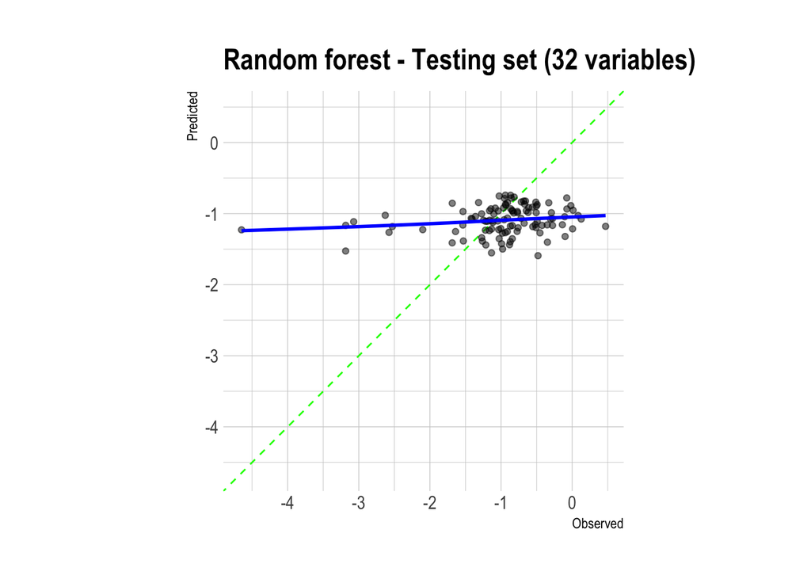

# Delirium prediction - model fit

The elastic net models were fit on four variable sets across two modeling approaches:

- The variable sets:
  - The first 15 PCA components from the set of 93 variables.
  - The set of 7 PCA components from the 7 variables that had three or more votes from the expert panel
  - The set of 14 PCA components from the 14 variables that had two or more votes from the expert panel
  - The first 15 PCA components from the 32 variables that had one or more votes from the expert panel
- The models:
  - original PCA components
  - restricted cubic splines of the first 15 PCA components

The random forest models were fit on four variable sets:

- The variable sets:
  - The first 15 PCA components from the set of 93 variables.
  - The set of 7 PCA components from the 7 variables that had three or more votes from the expert panel
  - The set of 14 PCA components from the 14 variables that had two or more votes from the expert panel
  - The first 15 PCA components from the 32 variables that had one or more votes from the expert panel

**Model tuning**

The training data was into 10 cross-validation sets.

The models were tuned to maximize the kappa statistic.

The elastic net models were tuned using 25 sets of possible values.

These are the hyperparameters that were tuned:

- Elastic net: alpha (mixture between lasso and ridge regression) and penalty term

The random forest models were tuned using 40 sets of possible values.

These are the hyperparameters that were tuned:

- Random forest: number of trees and minimum sample size per node

## GLMNET

### Original PCA components

#### Performance in testing set

Model using the first 15 of 93 PCA components.

```
# A tibble: 3 × 4
  .metric  .estimator .estimate .config
  <chr>    <chr>          <dbl> <chr>
1 accuracy binary         0.848 Preprocessor1_Model1
2 kap      binary         0.215 Preprocessor1_Model1
3 roc_auc  binary         0.587 Preprocessor1_Model1
```

|  | vdsagesdeliriumever No Delirium | vdsagesdeliriumever Delirium | Total |  |
| --- | --- | --- | --- | --- |
| .pred_class |  |  |  |  |
| No Delirium | 92 | 16 | 108 |  |
| Delirium | 1 | 3 | 4 |  |
| Total | 93 | 19 | 112 |  |

Model using the 7 PCA components from variables that had three or more votes from the expert panel.

```
# A tibble: 3 × 4
  .metric  .estimator .estimate .config
  <chr>    <chr>          <dbl> <chr>
1 accuracy binary         0.821 Preprocessor1_Model1
2 kap      binary         0.103 Preprocessor1_Model1
3 roc_auc  binary         0.596 Preprocessor1_Model1
```

|  | vdsagesdeliriumever No Delirium | vdsagesdeliriumever Delirium | Total |  |
| --- | --- | --- | --- | --- |
| .pred_class |  |  |  |  |
| No Delirium | 90 | 17 | 107 |  |
| Delirium | 3 | 2 | 5 |  |
| Total | 93 | 19 | 112 |  |

Model using the 14 PCA components from variables that had two or more votes from the expert panel.

```
# A tibble: 3 × 4
  .metric  .estimator .estimate .config
  <chr>    <chr>          <dbl> <chr>
1 accuracy binary         0.839 Preprocessor1_Model1
2 kap      binary         0.193 Preprocessor1_Model1
3 roc_auc  binary         0.616 Preprocessor1_Model1
```

|  | vdsagesdeliriumever No Delirium | vdsagesdeliriumever Delirium | Total |  |
| --- | --- | --- | --- | --- |
| .pred_class |  |  |  |  |
| No Delirium | 91 | 16 | 107 |  |
| Delirium | 2 | 3 | 5 |  |
| Total | 93 | 19 | 112 |  |

Model using the first 15 of 32 PCA components from variables that had one or more votes from the expert panel.

```
# A tibble: 3 × 4
  .metric  .estimator .estimate .config
  <chr>    <chr>          <dbl> <chr>
1 accuracy binary         0.848 Preprocessor1_Model1
2 kap      binary         0.215 Preprocessor1_Model1
3 roc_auc  binary         0.587 Preprocessor1_Model1
```

|  | vdsagesdeliriumever No Delirium | vdsagesdeliriumever Delirium | Total |  |
| --- | --- | --- | --- | --- |
| .pred_class |  |  |  |  |
| No Delirium | 92 | 16 | 108 |  |
| Delirium | 1 | 3 | 4 |  |
| Total | 93 | 19 | 112 |  |

## Restricted cubic splines

#### Performance in testing set

Model using the first 15 of 93 PCA components.

```
# A tibble: 3 × 4
  .metric  .estimator .estimate .config
  <chr>    <chr>          <dbl> <chr>
1 accuracy binary         0.848 Preprocessor1_Model1
2 kap      binary         0.3   Preprocessor1_Model1
3 roc_auc  binary         0.611 Preprocessor1_Model1
```

|  | vdsagesdeliriumever No Delirium | vdsagesdeliriumever Delirium | Total |  |
| --- | --- | --- | --- | --- |
| .pred_class |  |  |  |  |
| No Delirium | 90 | 14 | 104 |  |
| Delirium | 3 | 5 | 8 |  |
| Total | 93 | 19 | 112 |  |

Model using the 7 PCA components from variables that had three or more votes from the expert panel.

```
# A tibble: 3 × 4
  .metric  .estimator .estimate .config
  <chr>    <chr>          <dbl> <chr>
1 accuracy binary         0.830 Preprocessor1_Model1
2 kap      binary         0.122 Preprocessor1_Model1
3 roc_auc  binary         0.596 Preprocessor1_Model1
```

|  | vdsagesdeliriumever No Delirium | vdsagesdeliriumever Delirium | Total |  |
| --- | --- | --- | --- | --- |
| .pred_class |  |  |  |  |
| No Delirium | 91 | 17 | 108 |  |
| Delirium | 2 | 2 | 4 |  |
| Total | 93 | 19 | 112 |  |

Model using the 14 PCA components from variables that had two or more votes from the expert panel.

```
# A tibble: 3 × 4
  .metric  .estimator .estimate .config
  <chr>    <chr>          <dbl> <chr>
1 accuracy binary         0.848 Preprocessor1_Model1
2 kap      binary         0.260 Preprocessor1_Model1
3 roc_auc  binary         0.626 Preprocessor1_Model1
```

|  | vdsagesdeliriumever No Delirium | vdsagesdeliriumever Delirium | Total |  |
| --- | --- | --- | --- | --- |
| .pred_class |  |  |  |  |
| No Delirium | 91 | 15 | 106 |  |
| Delirium | 2 | 4 | 6 |  |
| Total | 93 | 19 | 112 |  |

Model using the first 15 of 32 PCA components from variables that had one or more votes from the expert panel.

```
# A tibble: 3 × 4
  .metric  .estimator .estimate .config
  <chr>    <chr>          <dbl> <chr>
1 accuracy binary         0.848 Preprocessor1_Model1
2 kap      binary         0.3   Preprocessor1_Model1
3 roc_auc  binary         0.611 Preprocessor1_Model1
```

|  | vdsagesdeliriumever No Delirium | vdsagesdeliriumever Delirium | Total |  |
| --- | --- | --- | --- | --- |
| .pred_class |  |  |  |  |
| No Delirium | 90 | 14 | 104 |  |
| Delirium | 3 | 5 | 8 |  |
| Total | 93 | 19 | 112 |  |

## Random forest

### Original PCA components

#### Performance in testing set

Model using the first 15 of 93 PCA components.

```
# A tibble: 3 × 4
  .metric  .estimator .estimate .config
  <chr>    <chr>          <dbl> <chr>
1 accuracy binary         0.821 Preprocessor1_Model1
2 kap      binary         0.103 Preprocessor1_Model1
3 roc_auc  binary         0.595 Preprocessor1_Model1
```

|  | vdsagesdeliriumever No Delirium | vdsagesdeliriumever Delirium | Total |  |
| --- | --- | --- | --- | --- |
| .pred_class |  |  |  |  |
| No Delirium | 90 | 17 | 107 |  |
| Delirium | 3 | 2 | 5 |  |
| Total | 93 | 19 | 112 |  |

Model using the 7 PCA components from variables that had three or more votes from the expert panel.

```
# A tibble: 3 × 4
  .metric  .estimator .estimate .config
  <chr>    <chr>          <dbl> <chr>
1 accuracy binary        0.795  Preprocessor1_Model1
2 kap      binary        0.0529 Preprocessor1_Model1
3 roc_auc  binary        0.545  Preprocessor1_Model1
```

|  | vdsagesdeliriumever No Delirium | vdsagesdeliriumever Delirium | Total |  |
| --- | --- | --- | --- | --- |
| .pred_class |  |  |  |  |
| No Delirium | 87 | 17 | 104 |  |
| Delirium | 6 | 2 | 8 |  |
| Total | 93 | 19 | 112 |  |

Model using the 14 PCA components from variables that had two or more votes from the expert panel.

```
# A tibble: 3 × 4
  .metric  .estimator .estimate .config
  <chr>    <chr>          <dbl> <chr>
1 accuracy binary         0.821 Preprocessor1_Model1
2 kap      binary         0.153 Preprocessor1_Model1
3 roc_auc  binary         0.586 Preprocessor1_Model1
```

|  | vdsagesdeliriumever No Delirium | vdsagesdeliriumever Delirium | Total |  |
| --- | --- | --- | --- | --- |
| .pred_class |  |  |  |  |
| No Delirium | 89 | 16 | 105 |  |
| Delirium | 4 | 3 | 7 |  |
| Total | 93 | 19 | 112 |  |

Model using the first 15 of 32 PCA components from variables that had one or more votes from the expert panel.

```
# A tibble: 3 × 4
  .metric  .estimator .estimate .config
  <chr>    <chr>          <dbl> <chr>
1 accuracy binary         0.821 Preprocessor1_Model1
2 kap      binary         0.103 Preprocessor1_Model1
3 roc_auc  binary         0.583 Preprocessor1_Model1
```

|  | vdsagesdeliriumever No Delirium | vdsagesdeliriumever Delirium | Total |  |
| --- | --- | --- | --- | --- |
| .pred_class |  |  |  |  |
| No Delirium | 90 | 17 | 107 |  |
| Delirium | 3 | 2 | 5 |  |
| Total | 93 | 19 | 112 |  |